# AirBnB Analysis

**PANDAS LAB**

```python
import pandas as pd
```

```python
# import dataset
file= '/Users/Dell/Documents/3mtt project/dataset/AB_NYC_2019.csv'
data= pd.read_csv(file)
```

```python
data.head()
```

|  | id | name | host_id | host_name | neighbourhood_group | neighbourhood | latitude | longitude | room_type | price | minimum_nights | number_of_reviews | last_review | reviews_per_month | calculated_host_listings_count | availability_365 |
| --- | --- | --- | --- | --- | --- | --- | --- | --- | --- | --- | --- | --- | --- | --- | --- | --- |
| 0 | 2539 | Clean & quiet apt home by the park | 2787 | John | Brooklyn | Kensington | 40.64749 | -73.97237 | Private room | 149 | 1 | 9 | 2018-10-19 | 0.21 | 6 | 365 |
| 1 | 2595 | Skylit Midtown Castle | 2845 | Jennifer | Manhattan | Midtown | 40.75362 | -73.98377 | Entire home/apt | 225 | 1 | 45 | 2019-05-21 | 0.38 | 2 | 355 |
| 2 | 3647 | THE VILLAGE OF HARLEM....NEW YORK ! | 4632 | Elisabeth | Manhattan | Harlem | 40.80902 | -73.94190 | Private room | 150 | 3 | 0 | NaN | NaN | 1 | 365 |
| 3 | 3831 | Cozy Entire Floor of Brownstone | 4869 | LisaRoxanne | Brooklyn | Clinton Hill | 40.68514 | -73.95976 | Entire home/apt | 89 | 1 | 270 | 2019-07-05 | 4.64 | 1 | 194 |
| 4 | 5022 | Entire Apt: Spacious Studio/Loft by central park | 7192 | Laura | Manhattan | East Harlem | 40.79851 | -73.94399 | Entire home/apt | 80 | 10 | 9 | 2018-11-19 | 0.10 | 1 | 0 |

```python
data.duplicated().sum()
```

```
0
```

```python
data.tail()
```

|  | id | name | host_id | host_name | neighbourhood_group | neighbourhood | latitude | longitude | room_type | price | minimum_nights | number_of_reviews | last_review | reviews_per_month | calculated_host_listings_count | availability_365 |
| --- | --- | --- | --- | --- | --- | --- | --- | --- | --- | --- | --- | --- | --- | --- | --- | --- |
| 48890 | 36484665 | Charming one bedroom - newly renovated rowhouse | 8232441 | Sabrina | Brooklyn | Bedford-Stuyvesant | 40.67853 | -73.94995 | Private room | 70 | 2 | 0 | NaN | NaN | 2 | 9 |
| 48891 | 36485057 | Affordable room in Bushwick/East Williamsburg | 6570630 | Marisol | Brooklyn | Bushwick | 40.70184 | -73.93317 | Private room | 40 | 4 | 0 | NaN | NaN | 2 | 36 |
| 48892 | 36485431 | Sunny Studio at Historical Neighborhood | 23492952 | Ilgar & Aysel | Manhattan | Harlem | 40.81475 | -73.94867 | Entire home/apt | 115 | 10 | 0 | NaN | NaN | 1 | 27 |
| 48893 | 36485609 | 43rd St. Time Square-cozy single bed | 30985759 | Taz | Manhattan | Hell's Kitchen | 40.75751 | -73.99112 | Shared room | 55 | 1 | 0 | NaN | NaN | 6 | 2 |
| 48894 | 36487245 | Trendy duplex in the very heart of Hell's Kitchen | 68119814 | Christophe | Manhattan | Hell's Kitchen | 40.76404 | -73.98933 | Private room | 90 | 7 | 0 | NaN | NaN | 1 | 23 |

```python
# check for missing data. Categorical fill with mode, numerical is filled with mean. And it can be completly removed.
```

```python
data.columns
```

```
Index(['id', 'name', 'host_id', 'host_name', 'neighbourhood_group',
       'neighbourhood', 'latitude', 'longitude', 'room_type', 'price',
       'minimum_nights', 'number_of_reviews', 'last_review',
       'reviews_per_month', 'calculated_host_listings_count',
       'availability_365'],
      dtype='object')
```

```python
data.shape
```

```
(48895, 16)
```

```python
data.size
```

```
782320
```

**DATA CLEANING**

**Handle Missing Data**

- Numerial data - Mean
- Categorical data - Mode

**Handing duplicate value**

- **data.duplicated().sum()---- to check for duplicate value**
- **data.drop_duplicate(inplace=True)---- This is to drop duplicate value in data**a

```python
data.info()
```

```
<class 'pandas.core.frame.DataFrame'>
RangeIndex: 48895 entries, 0 to 48894
Data columns (total 16 columns):
 #   Column                          Non-Null Count  Dtype
---  ------                          --------------  -----
 0   id                              48895 non-null  int64
 1   name                            48879 non-null  object
 2   host_id                         48895 non-null  int64
 3   host_name                       48874 non-null  object
 4   neighbourhood_group             48895 non-null  object
 5   neighbourhood                   48895 non-null  object
 6   latitude                        48895 non-null  float64
 7   longitude                       48895 non-null  float64
 8   room_type                       48895 non-null  object
 9   price                           48895 non-null  int64
 10  minimum_nights                  48895 non-null  int64
 11  number_of_reviews               48895 non-null  int64
 12  last_review                     38843 non-null  object
 13  reviews_per_month               38843 non-null  float64
 14  calculated_host_listings_count  48895 non-null  int64
 15  availability_365                48895 non-null  int64
dtypes: float64(3), int64(7), object(6)
memory usage: 6.0+ MB
```

```python
data['name'].mode()
```

```
0    Hillside Hotel
Name: name, dtype: object
```

```python
mode1= data['name'].mode()[0]
mode1
```

```
'Hillside Hotel'
```

```python
data['name'].fillna(mode1,inplace=True)
```

```python
data.isna().sum()
```

```
id                                    0
name                                  0
host_id                               0
host_name                            21
neighbourhood_group                   0
neighbourhood                         0
latitude                              0
longitude                             0
room_type                             0
price                                 0
minimum_nights                        0
number_of_reviews                     0
last_review                       10052
reviews_per_month                 10052
calculated_host_listings_count        0
availability_365                      0
dtype: int64
```

```python
mode1= data['host_name'].mode()[0]
mode1
```

```
'Michael'
```

```python
data['host_name'].fillna(mode1,inplace=True)
```

```python
data.isna().sum()
```

```
id                                    0
name                                  0
host_id                               0
host_name                             0
neighbourhood_group                   0
neighbourhood                         0
latitude                              0
longitude                             0
room_type                             0
price                                 0
minimum_nights                        0
number_of_reviews                     0
last_review                       10052
reviews_per_month                 10052
calculated_host_listings_count        0
availability_365                      0
dtype: int64
```

```python
mode1= data['last_review'].mode()[0]
mode1
```

```
'2019-06-23'
```

```python
data['last_review'].fillna(mode1,inplace=True)
```

```python
data.isna().sum()
```

```
id                                    0
name                                  0
host_id                               0
host_name                             0
neighbourhood_group                   0
neighbourhood                         0
latitude                              0
longitude                             0
room_type                             0
price                                 0
minimum_nights                        0
number_of_reviews                     0
last_review                           0
reviews_per_month                 10052
calculated_host_listings_count        0
availability_365                      0
dtype: int64
```

```python
mean= data['reviews_per_month'].mean()
mean
```

```
1.3732214298586618
```

```python
data['reviews_per_month'].fillna(mean,inplace=True)
```

```python
data.isna().sum()
```

```
id                                0
name                              0
host_id                           0
host_name                         0
neighbourhood_group               0
neighbourhood                     0
latitude                          0
longitude                         0
room_type                         0
price                             0
minimum_nights                    0
number_of_reviews                 0
last_review                       0
reviews_per_month                 0
calculated_host_listings_count    0
availability_365                  0
dtype: int64
```

**Data.dropna() axis=0,inplace=True,how='any' to remove rows**

**Data.dropna() axis=1,inplace=True,how='any' to remove columns**

**Conditions for missing value**

**Data.dropna() axis=1,inplace=True,Treach='value'**

**EDA Exploratory Data Analysis**

**Univariate = Exploring 1 variables**

**Bivariate = EXploring 2 dependent variable with respect to independent variable**

**Multivariate is 3 or more**

**EDA Univeriate Analysis**

```python
len(data)
```

```
48895
```

```python
len(data)*0.5
```

```
24447.5
```

```python
data['price'].mean()
```

```
152.7206871868289
```

```python
data['price'].mode()
```

```
0    100
Name: price, dtype: int64
```

```python
data['price'].std()
```

```
240.15416974718727
```

```python
data['price'].value_counts()
```

```
price
100    2051
150    2047
50     1534
60     1458
200    1401
       ...
780       1
386       1
888       1
483       1
338       1
Name: count, Length: 674, dtype: int64
```

```python
data['name'].value_counts()
```

```
name
Hillside Hotel                                        34
Home away from home                                   17
New york Multi-unit building                          16
Brooklyn Apartment                                    12
Private Room                                          11
                                                      ..
Large 1BR Apt. in Williamsburg                         1
Feel at Home                                           1
Spacious Modern Alcove Studio in a Luxury Building     1
Artist's Room in Large Apartment                       1
Trendy duplex in the very heart of Hell's Kitchen      1
Name: count, Length: 47905, dtype: int64
```

```python
import matplotlib.pyplot as plt
import seaborn as sns
```

```python
price_freq=data['price'].value_counts()
price_freq
```

```
price
100    2051
150    2047
50     1534
60     1458
200    1401
       ...
780       1
386       1
888       1
483       1
338       1
Name: count, Length: 674, dtype: int64
```

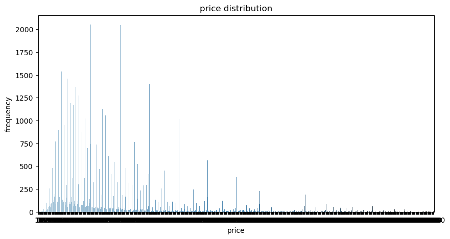

```python
## plot of price Distribution
plt.figure(figsize=(10,5))
sns.barplot(x=price_freq.index,y=price_freq.values,palette='Blues_d')
plt.title('price distribution')
plt.xlabel('price')
plt.ylabel('frequency')
plt.show()
```

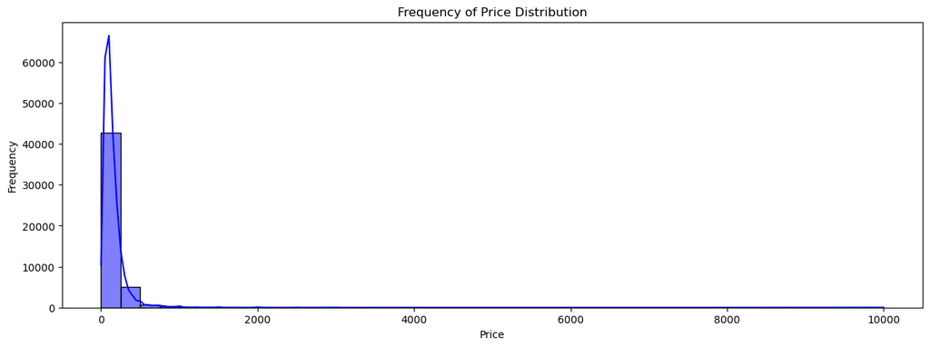

```python
# plot of price distribution (Histogram)
plt.figure(figsize=(15,5))
sns.histplot(data['price'], bins=40, kde=True, color='Blue')
plt.title('Frequency of Price Distribution')
plt.xlabel('Price')
plt.ylabel('Frequency')
plt.show()
```

**Insight**

- The price distribution shows a +ve/right skewed data.
- The plot shows that there are a few outliers in the data distribution e.g. 6,000 - 10,000
- This implies that there are more low-income to middle-income customers.rs.

```python
max_price = data['price'].max()
max_price
```

```
10000
```

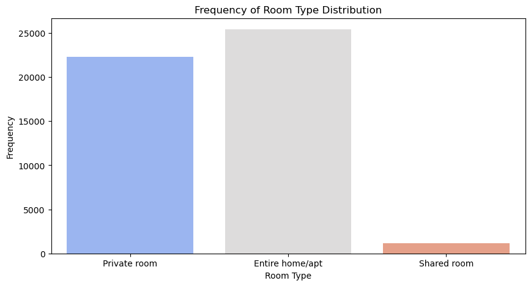

```python
# plot of room_type diatribution (countplot)
plt.figure(figsize=(10,5))
sns.countplot(x='room_type', data=data, palette='coolwarm')
plt.title('Frequency of Room Type Distribution')
plt.xlabel('Room Type')
plt.ylabel('Frequency')
plt.show()
```

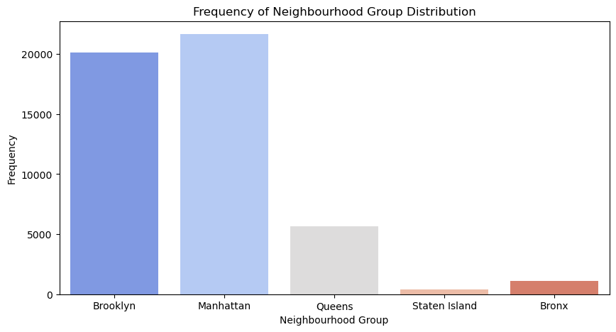

```python
# plot of neighbourhood_group distribution (countplot)
plt.figure(figsize=(10,5))
sns.countplot(x='neighbourhood_group', data=data, palette='coolwarm')
plt.title('Frequency of Neighbourhood Group Distribution')
plt.xlabel('Neighbourhood Group')
plt.ylabel('Frequency')
plt.show()
```

**EDA; Bivariate Analysis**

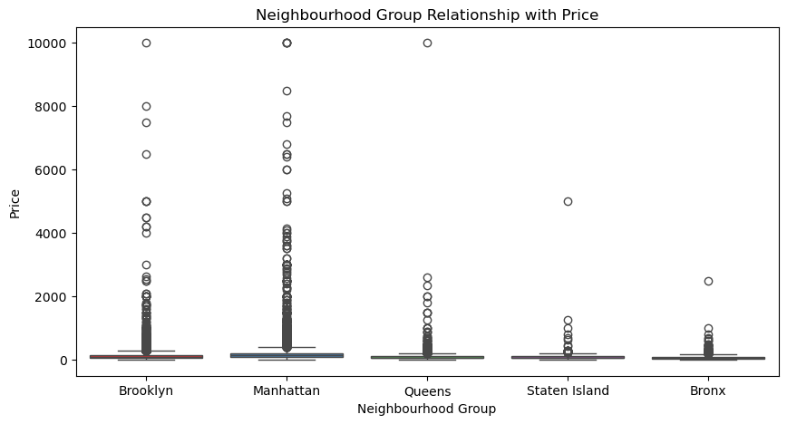

```python
# plot of neighbourhood_group distribution and price distribution (boxtplot)
plt.figure(figsize=(10,5))
sns.boxplot(x='neighbourhood_group', y='price', data=data, palette='Set1')
plt.title('Neighbourhood Group Relationship with Price')
plt.xlabel('Neighbourhood Group')
plt.ylabel('Price')
plt.show()
```

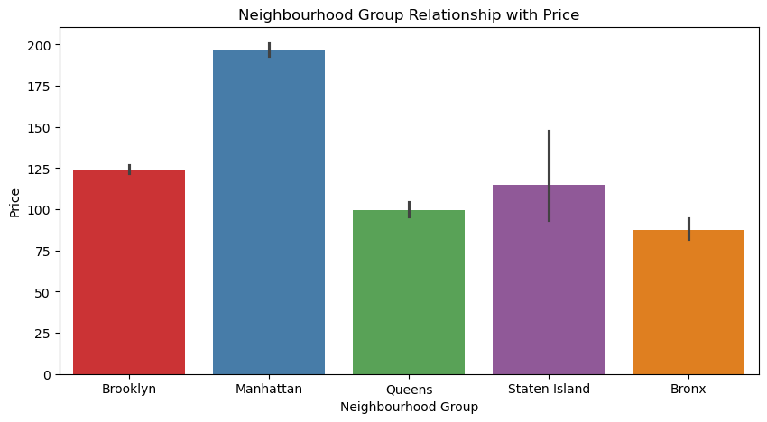

```python
# plot of neighbourhood_group distribution and price distribution (barplot)
plt.figure(figsize=(10,5))
sns.barplot(x='neighbourhood_group', y='price', data=data, palette='Set1')
plt.title('Neighbourhood Group Relationship with Price')
plt.xlabel('Neighbourhood Group')
plt.ylabel('Price')
plt.show()
```

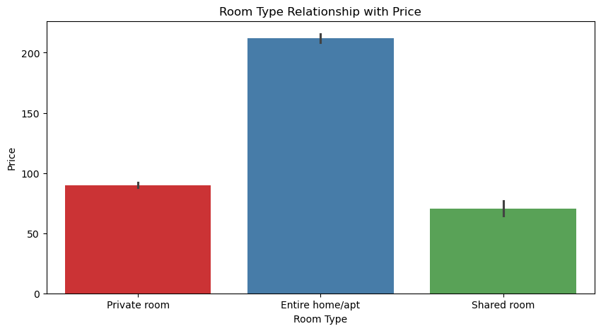

```python
# plot of room type and price distribution (bartplot)
plt.figure(figsize=(10,5))
sns.barplot(x='room_type', y='price', data=data, palette='Set1')
plt.title('Room Type Relationship with Price')
plt.xlabel('Room Type')
plt.ylabel('Price')
plt.show()
```

**Get Correlation WRT Price**

```python
data.info()
```

```
<class 'pandas.core.frame.DataFrame'>
RangeIndex: 48895 entries, 0 to 48894
Data columns (total 16 columns):
 #   Column                          Non-Null Count  Dtype
---  ------                          --------------  -----
 0   id                              48895 non-null  int64
 1   name                            48895 non-null  object
 2   host_id                         48895 non-null  int64
 3   host_name                       48895 non-null  object
 4   neighbourhood_group             48895 non-null  object
 5   neighbourhood                   48895 non-null  object
 6   latitude                        48895 non-null  float64
 7   longitude                       48895 non-null  float64
 8   room_type                       48895 non-null  object
 9   price                           48895 non-null  int64
 10  minimum_nights                  48895 non-null  int64
 11  number_of_reviews               48895 non-null  int64
 12  last_review                     48895 non-null  object
 13  reviews_per_month               48895 non-null  float64
 14  calculated_host_listings_count  48895 non-null  int64
 15  availability_365                48895 non-null  int64
dtypes: float64(3), int64(7), object(6)
memory usage: 6.0+ MB
```

```python
# work with only numerical data
numerical_data = data.select_dtypes(include=['int64', 'float64'])
numerical_data.head()
```

|  | id | host_id | latitude | longitude | price | minimum_nights | number_of_reviews | reviews_per_month | calculated_host_listings_count | availability_365 |
| --- | --- | --- | --- | --- | --- | --- | --- | --- | --- | --- |
| 0 | 2539 | 2787 | 40.64749 | -73.97237 | 149 | 1 | 9 | 0.210000 | 6 | 365 |
| 1 | 2595 | 2845 | 40.75362 | -73.98377 | 225 | 1 | 45 | 0.380000 | 2 | 355 |
| 2 | 3647 | 4632 | 40.80902 | -73.94190 | 150 | 3 | 0 | 1.373221 | 1 | 365 |
| 3 | 3831 | 4869 | 40.68514 | -73.95976 | 89 | 1 | 270 | 4.640000 | 1 | 194 |
| 4 | 5022 | 7192 | 40.79851 | -73.94399 | 80 | 10 | 9 | 0.100000 | 1 | 0 |

```python
# Get correlation of dataset
#you can either work with 1.) only numerical data or 2.) covert all columns to numeric
corr_matrix1 = numerical_data.corr()
corr_matrix1
```

|  | id | host_id | latitude | longitude | price | minimum_nights | number_of_reviews | reviews_per_month | calculated_host_listings_count | availability_365 |
| --- | --- | --- | --- | --- | --- | --- | --- | --- | --- | --- |
| id | 1.000000 | 0.588290 | -0.003125 | 0.090908 | 0.010619 | -0.013224 | -0.319760 | 0.253252 | 0.133272 | 0.085468 |
| host_id | 0.588290 | 1.000000 | 0.020224 | 0.127055 | 0.015309 | -0.017364 | -0.140106 | 0.255046 | 0.154950 | 0.203492 |
| latitude | -0.003125 | 0.020224 | 1.000000 | 0.084788 | 0.033939 | 0.024869 | -0.015389 | -0.009115 | 0.019517 | -0.010983 |
| longitude | 0.090908 | 0.127055 | 0.084788 | 1.000000 | -0.150019 | -0.062747 | 0.059094 | 0.131599 | -0.114713 | 0.082731 |
| price | 0.010619 | 0.015309 | 0.033939 | -0.150019 | 1.000000 | 0.042799 | -0.047954 | -0.022373 | 0.057472 | 0.081829 |
| minimum_nights | -0.013224 | -0.017364 | 0.024869 | -0.062747 | 0.042799 | 1.000000 | -0.080116 | -0.091942 | 0.127960 | 0.144303 |
| number_of_reviews | -0.319760 | -0.140106 | -0.015389 | 0.059094 | -0.047954 | -0.080116 | 1.000000 | 0.530093 | -0.072376 | 0.172028 |
| reviews_per_month | 0.253252 | 0.255046 | -0.009115 | 0.131599 | -0.022373 | -0.091942 | 0.530093 | 1.000000 | -0.006701 | 0.162980 |
| calculated_host_listings_count | 0.133272 | 0.154950 | 0.019517 | -0.114713 | 0.057472 | 0.127960 | -0.072376 | -0.006701 | 1.000000 | 0.225701 |
| availability_365 | 0.085468 | 0.203492 | -0.010983 | 0.082731 | 0.081829 | 0.144303 | 0.172028 | 0.162980 | 0.225701 | 1.000000 |

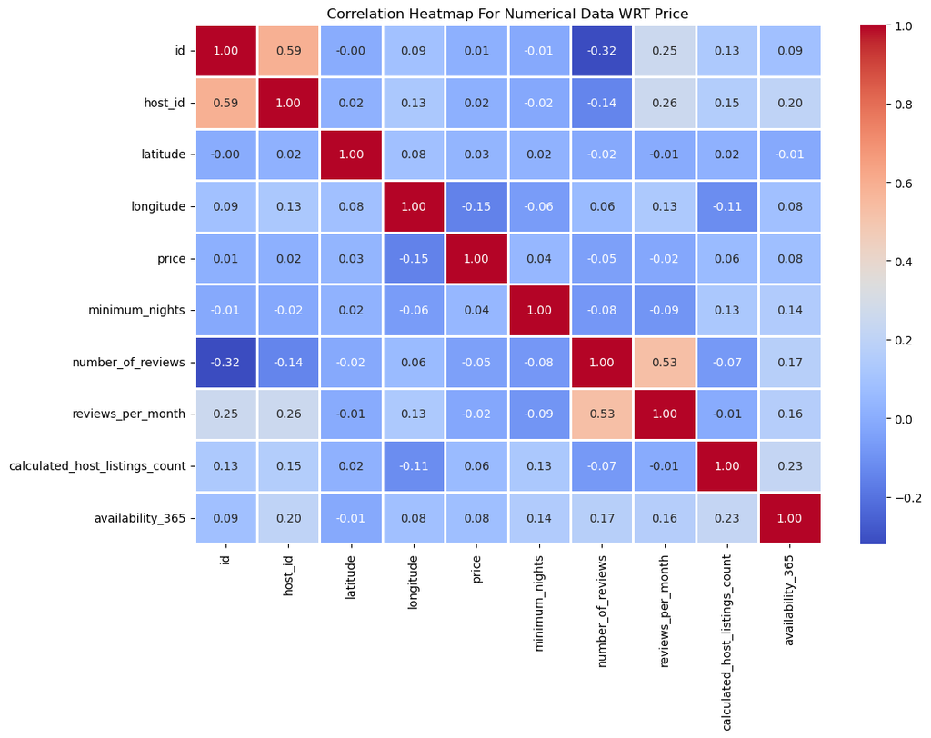

```python
# Correlation Heatmap

plt.figure(figsize=(12,8))
sns.heatmap(corr_matrix1, annot=True, cmap='coolwarm', fmt='.2f', linewidths=1.0)
plt.title('Correlation Heatmap For Numerical Data WRT Price')
plt.show()
```

**STATISTICAL ANALYSIS CONCEPT**

statistical analysis is the process of collecting, exploration, extracting information from data using statistical tools and method.

```python
data.describe()
```

|  | id | host_id | latitude | longitude | price | minimum_nights | number_of_reviews | reviews_per_month | calculated_host_listings_count | availability_365 |
| --- | --- | --- | --- | --- | --- | --- | --- | --- | --- | --- |
| count | 4.889500e+04 | 4.889500e+04 | 48895.000000 | 48895.000000 | 48895.000000 | 48895.000000 | 48895.000000 | 48895.000000 | 48895.000000 | 48895.000000 |
| mean | 1.901714e+07 | 6.762001e+07 | 40.728949 | -73.952170 | 152.720687 | 7.029962 | 23.274466 | 1.373221 | 7.143982 | 112.781327 |
| std | 1.098311e+07 | 7.861097e+07 | 0.054530 | 0.046157 | 240.154170 | 20.510550 | 44.550582 | 1.497775 | 32.952519 | 131.622289 |
| min | 2.539000e+03 | 2.438000e+03 | 40.499790 | -74.244420 | 0.000000 | 1.000000 | 0.000000 | 0.010000 | 1.000000 | 0.000000 |
| 25% | 9.471945e+06 | 7.822033e+06 | 40.690100 | -73.983070 | 69.000000 | 1.000000 | 1.000000 | 0.280000 | 1.000000 | 0.000000 |
| 50% | 1.967728e+07 | 3.079382e+07 | 40.723070 | -73.955680 | 106.000000 | 3.000000 | 5.000000 | 1.220000 | 1.000000 | 45.000000 |
| 75% | 2.915218e+07 | 1.074344e+08 | 40.763115 | -73.936275 | 175.000000 | 5.000000 | 24.000000 | 1.580000 | 2.000000 | 227.000000 |
| max | 3.648724e+07 | 2.743213e+08 | 40.913060 | -73.712990 | 10000.000000 | 1250.000000 | 629.000000 | 58.500000 | 327.000000 | 365.000000 |

```python
data.info()
```

```
<class 'pandas.core.frame.DataFrame'>
RangeIndex: 48895 entries, 0 to 48894
Data columns (total 16 columns):
 #   Column                          Non-Null Count  Dtype
---  ------                          --------------  -----
 0   id                              48895 non-null  int64
 1   name                            48895 non-null  object
 2   host_id                         48895 non-null  int64
 3   host_name                       48895 non-null  object
 4   neighbourhood_group             48895 non-null  object
 5   neighbourhood                   48895 non-null  object
 6   latitude                        48895 non-null  float64
 7   longitude                       48895 non-null  float64
 8   room_type                       48895 non-null  object
 9   price                           48895 non-null  int64
 10  minimum_nights                  48895 non-null  int64
 11  number_of_reviews               48895 non-null  int64
 12  last_review                     48895 non-null  object
 13  reviews_per_month               48895 non-null  float64
 14  calculated_host_listings_count  48895 non-null  int64
 15  availability_365                48895 non-null  int64
dtypes: float64(3), int64(7), object(6)
memory usage: 6.0+ MB
```

**HYPOTESIS FORMULATION/TESTING**

**HYPOTHESIS 2:** MINIMUM NIGHTS VS PRICE

- **NULL HYPOTHESIS (H0):** There is no linear relationship between the number of minimum nights spent and the price.
- **ALTERNATIVE HYPOTHESIS (H1):** There is a linear relationship between the number of minimum nights spent and the price.

```python
# using pearson correlation technique
import scipy.stats as stats
```

```python
selected_data = data[['price', 'minimum_nights']]
selected_data.isna().sum()
```

```
price             0
minimum_nights    0
dtype: int64
```

```python
# get pearson correlation between the two variables
pearson_value, p_value = stats.pearsonr(selected_data['price'],selected_data['minimum_nights'])
```

```python
data.info()
```

```
<class 'pandas.core.frame.DataFrame'>
RangeIndex: 48895 entries, 0 to 48894
Data columns (total 16 columns):
 #   Column                          Non-Null Count  Dtype
---  ------                          --------------  -----
 0   id                              48895 non-null  int64
 1   name                            48895 non-null  object
 2   host_id                         48895 non-null  int64
 3   host_name                       48895 non-null  object
 4   neighbourhood_group             48895 non-null  object
 5   neighbourhood                   48895 non-null  object
 6   latitude                        48895 non-null  float64
 7   longitude                       48895 non-null  float64
 8   room_type                       48895 non-null  object
 9   price                           48895 non-null  int64
 10  minimum_nights                  48895 non-null  int64
 11  number_of_reviews               48895 non-null  int64
 12  last_review                     48895 non-null  object
 13  reviews_per_month               48895 non-null  float64
 14  calculated_host_listings_count  48895 non-null  int64
 15  availability_365                48895 non-null  int64
dtypes: float64(3), int64(7), object(6)
memory usage: 6.0+ MB
```

```python
x = round(pearson_value,4)
y = p_value
print(f'pearson correlation value of selected_data is {x} and p_value is {y}')
```

```
pearson correlation value of selected_data is 0.0428 and p_value is 2.8531707316187487e-21
```

**Summary**

- Since the p_value is less than 0.05, we reject the num hypothesis because there is a relationship between price and minimum nights spent.

**CHI SQUARE TEST**

```python
# create a contigency table
cont_table = pd.crosstab(data['neighbourhood_group'], data['room_type'])
cont_table
```

| room_type neighbourhood_group | Entire home/apt | Private room | Shared room |
| --- | --- | --- | --- |
| Bronx | 379 | 652 | 60 |
| Brooklyn | 9559 | 10132 | 413 |
| Manhattan | 13199 | 7982 | 480 |
| Queens | 2096 | 3372 | 198 |
| Staten Island | 176 | 188 | 9 |

```python
# H0 -> There's no relationship between the two variables
# H1 -> There's a relationship between the two variables
```

**Get results**

**Insight**

**T-Test**

different from each other. Exammples of this include - Independent T-Test: This compares the means of two independent groups. - Paired T-Test: This compares means from the same group at different times. - One-Sample T-Test: This compares the mean of a single group against a known value or proposition mean.

- The T-Test can be used when we have one numerical and one categorical variable.

**Hypothesis Formulation:**

- H0: The means of the two groups are equal.
- H1: The means of the two groups are not equal.

```python
# Get values for the room type
room_types = data['room_type'].unique()
room_types
```

```
array(['Private room', 'Entire home/apt', 'Shared room'], dtype=object)
```

```python
# Example: We'll be exploring the room-type variable

# H0: The avg price of the the entire home apt is equal to the avg price for the private room
# H1: The avg price of the the entire home apt is NOT equal to the avg price for the private room

# Get the price for both groups
entire_home = data[data['room_type'] == 'Entire home/apt']['price']
entire_home
```

```
1        225
3         89
4         80
5        200
9        150
        ...
48879    120
48880    120
48886    200
48887    170
48892    115
Name: price, Length: 25409, dtype: int64
```

```python
# Get all prices for private room
private_room = data[data['room_type'] == 'Private room']['price']
private_room
```

```
0        149
2        150
6         60
7         79
8         79
        ...
48888    125
48889     65
48890     70
48891     40
48894     90
Name: price, Length: 22326, dtype: int64
```

```python
from scipy.stats import ttest_ind

# To perform the independent T-Test
t_stat, p_value = ttest_ind(entire_home, private_room, equal_var=False)

print(f'T-stat: {t_stat}')
print(f'P value: {p_value}')
```

```
T-stat: 58.67088986448112
P value: 0.0
```

**Insight**

- The p_value result shows that there's the avg prices of the etire home and the private room aren't the same. Hence, we reject the H0.
- The T-stat measures the standard deviation (std). It tells how far the sample mean std is from the population mean. The high value of 58.67 shows there's a large difference between the two variable groups.

Essentially, we're rejecting the null hypothesis as there's a significance between the avg prices of the groups.